# Parallelise DWBA sweeps with ZooScatR

Sven Gastauer

2019-10-16

This vignette will provide an introduction and one way of parallelising numerous DWBA simulations using ZooScatR and doSNOW as a [foreach](https://cran.r-project.org/web/packages/foreach/index.html) implementation within the [snow](https://cran.r-project.org/web/packages/snow/index.html) package (Alternatively [doParallel](https://cran.r-project.org/web/packages/doParallel/index.html) can be used, but this will make the progress bars malfunction). The vignette depends on ZooScatR, doSNOW, and Tcltk2. For plotting purposes [ggplot2](https://cran.r-project.org/web/packages/ggplot2/index.html), [viridis](https://cran.r-project.org/web/packages/viridis/index.html) and [reshape2](https://cran.r-project.org/web/packages/reshape2/index.html) are loaded.

This vignettes assumes that the user is familiar with the ZooScatR package and knows how to run the DWBA model from the command line within ZooScatR (see the general DWBA command line tutorial) and that a suitable config file for the model is available. If no config file is available, the easiest way to generate one is to use DWBAapp().

## Preparation

Load the necessary packages:

```r
#function to check if packages are available, otherwise installs them and loads them
libcheck <- function(x){
  for( i in x ){
    #  require returns TRUE invisibly if it was able to load package
    if( ! require( i , character.only = TRUE ) ){
      #  If package was not able to be loaded then re-install
      install.packages( i , dependencies = TRUE )
      #  Load package after installing
      require( i , character.only = TRUE )
    }
  }
}
#list of packages needed
libs = c("doSNOW", #for paralled process
         "tcltk2", #for os independent progressbar without RMarkdown output
         "ggplot2", #for plotting
         "viridis", #for nicer colors
         "reshape2") #reshaping the results dataframe to be used in ggplot
libcheck(libs)
```

### Config file settings

Set the path to the config file and read it in.  
If no custom config file has been created yet, some example config files can be found in the extdata/configs folder of the package:

```r
#Set filename for preset config file
fname = paste0(system.file(package="ZooScatR"),"/extdata/configs/config_krill.dat")
#Read configuration from file
para = read_para(fname)
#Define the soundspeed in the surrounding fluid
misc <- list(cw = 1460) #soundspeed m/s
```

### Define the variable ranges

Any of the variables contained within the parameters list could be varied. Here we will only focus on frequencies, length, orientation and shape profile.

#### Shape parameters

Define the length range:

```r
#set length and theta limits
#minimum and maximum length [mm], increment step
lmin = 30; lmax = 60; lincr = 1
```

Sometimes, a model config file was generated but should be run for a different shape or maybe the model should run for various shapes:

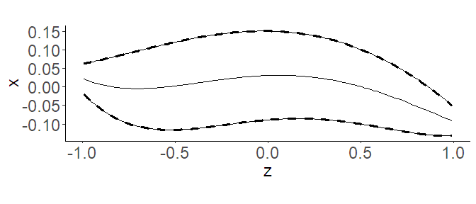

```r
#For a range of example profiles
profiles = paste0(paste0(system.file(package = "ZooScatR"),"/extdata/profiles/"),list.files(paste0(system.file(package = "ZooScatR"),"/extdata/profiles/"), pattern=".dat"))

#For this example we will only select a generic, hypothetical krill shape but set the parallel process to be able to cope with numerous profiles
profiles = paste0(paste0(system.file(package = "ZooScatR"),"/extdata/profiles/euphaus0.dat"))

#Check if the correct shape profile is selected:
para$shape$prof_name = profiles #Update the parameters (not necessary for the parallel process)
sprof = buildpos(para) #build the shape
sprof$plot #Check the shape plot
```

### Orientation parameters

Define the orientation ranges:

```r
#minimum and maximum theta, increment step
t_min = -90; t_max = 0; tincr = 10
```

### Simulation parameters

Define the frequencies:

```r
startfreq = 14; endfreq = 400; fincr = 1

para$simu$var0 <- startfreq #set starting frequency
para$simu$var1 <- endfreq #set end frequency
para$simu$n <- length(seq(para$simu$var0,para$simu$var1,by=fincr)) #number of output points based on the frequency range
```

## Model setup

### Progressbar

In a first step, we will calculate the total number of simulations we will have to run:

```r
#Total number of simulations
total <-length(seq(lmin,lmax,by=lincr))*
  length(seq(t_min,t_max,by=tincr))*
  length(profiles)*length(seq(startfreq,endfreq,by=fincr))
message(paste("The total number of simulations is:", total))
```

```
#> The total number of simulations is: 119970
```

Based on the number of simulations, we can initialise the progressbar:

```r
#pb <- tkProgressBar("ZooScatR - DWBA", "Initialising Model...", 0, total)
#progress <- function(n) {
#  info <- sprintf("Model progress: %d%% completed", round(n/total*100))
#  setTkProgressBar(pb, n, sprintf("test (%s)", info), info)
#  }
#opts <- list(progress = progress)
```

### Output filename

The model output will be saved as a csv and rds file.  
Here we set the filename (without format ending):

```r
out_fn = "TS_sim"
```

### Cluster initialisation

```r
#Set number of cores to be used:
ncl = 2
#Initialise the cluster in Snow
cl <- makeCluster(ncl)
registerDoSNOW(cl)
```

### Create foreach loop

```r
TS.df <- foreach(p=1:length(profiles), .combine=rbind) %:% #loop through profiles

  foreach(l = seq(lmin,lmax, by=lincr),.combine=rbind) %:% #loop through lengths

  foreach(theta = seq(t_min,t_max,by=tincr), #loop through orientations
          .combine=rbind, # make a rowbind of the results
          .packages=c("ZooScatR")) %dopar% { # bind ZooScatR to the loop
          #.options.snow = opts) %dopar% { # uncomment to show progress bar (commented for vignette)
            para$shape$prof_name = profiles[p] #load a preset shape
            para$shape$L <- l #set length
            para$orient$angm <- theta #set orientation

            # Run DWBA based on config file (invisible to suppress warnings)
            invisible(capture.output(res <- bscat(para=para, misc=misc)))
            res.df <- as.data.frame(t(res$y)) #store results in a dataframe
            names(res.df) <- res$var #Set the names of the datraframe header
            res.df$id <- para$shape$prof_name #set the profile name as id
            res.df$L <- para$shape$L #add length information
            res.df$theta <- para$orient$angm #add orientation informaiton
            res.df
            }
message("Finished simulations...")
```

```
#> Finished simulations...
```

Stop the progress bar and cluster:

```r
#close(pb) #Close progressbar and cluster
stopCluster(cl)
```

### Save results

```r
message("Saving files")
```

```
#> Saving files
```

```r
write.csv(file=paste0(out_fn,".csv"), TS.df)
#Check if file was written successfully
if(file.exists(paste0(out_fn,".csv"))){
  message(paste0(paste0(out_fn,".csv"), " Written sucessfully!"))
}else{message(paste0("ERROR WRITING ", paste0(out_fn,".csv")))}
```

```
#> TS_sim.csv Written sucessfully!
```

```r
saveRDS(TS.df,paste0(out_fn,".RDS"))
#Check if file was written successfully
if(file.exists(paste0(out_fn,".RDS"))){
  message(paste0(paste0(out_fn,".RDS"), " Written sucessfully!"))
}else{message(paste0("ERROR WRITING ", paste0(out_fn,".RDS")))}
```

```
#> TS_sim.RDS Written sucessfully!
```

### Plot some of the results

Make a raster plot of TS as a function of length and orientation for a given frequency.

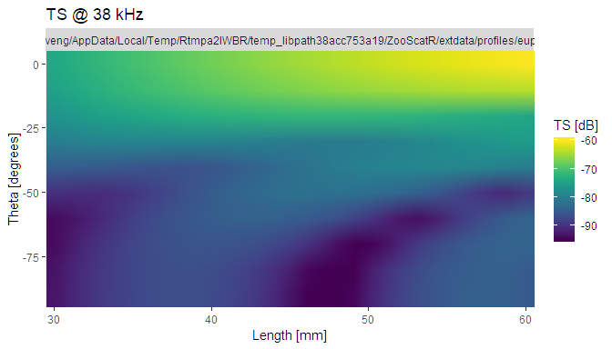

```r
ggts <- melt(TS.df, id=c("id","L","theta")) #melt data frame to be used in ggplot

#create the plot settings
TS_raster <- function(f){
  pp<- ggplot(data=ggts[ggts$variable==as.character(f),],aes(fill=value, x=L,y=theta))+
    facet_grid(.~id)+ #make grid for multiple profiles
    geom_raster(interpolate=TRUE)+ #make raster plot
    scale_fill_viridis(name="TS [dB]", limits=c(-95,-60), oob = scales::squish)+ #use viridis color scheme
    scale_x_continuous(expand = c(0,0))+ #remove white space on x axis
    scale_y_continuous(expand = c(0,0))+ #remove white space on y axis
    xlab("Length [mm]")+ylab("Theta [degrees]")+ #modify x and y axis labels
    ggtitle(paste("TS @",f,"kHz" ))
    theme_minimal()+ #use minimal theme
    theme(legend.position="top", #place legend on top
          axis.text = element_text(size=14), #change font size on x and y axis
          axis.title = element_text(size=16)) #change axis title font size
  print(pp)
}

#make plot at 38 kHz
TS_raster(38)
```

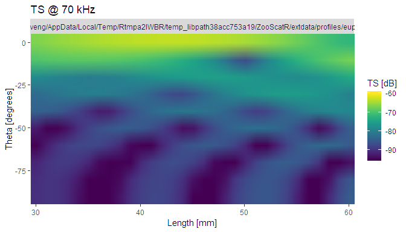

```r
#make plot at 70 kHz
TS_raster(70)
```

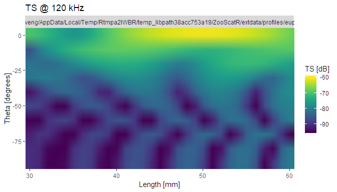

```r
#make plot at 120 kHz
TS_raster(120)
```

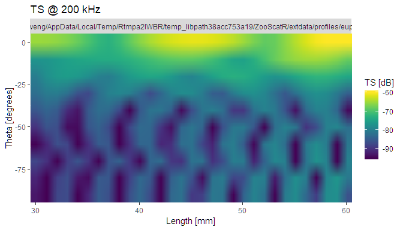

```r
#make plot at 200 kHz
TS_raster(200)
```

Plot the frequency response curves for selected lengths and orientations.  
Observe how the location and number of Nulls changes with respect to orientation and length.

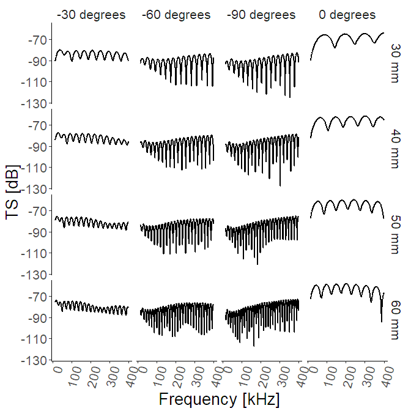

```r
f.cols <- 1:(length(TS.df)-3) #get the number of output points
TS.df[,f.cols] <- 10^(TS.df[,f.cols]/10) #linearise TS
vv2 <- which(TS.df$L %in% seq(10,100,by=10) & TS.df$theta %in% c(seq(-90,90,by=30))) #create a selection of the variable  values to be plotted
TS <- melt(TS.df[vv2,-which(names(TS.df)=="id")], id.vars=c("L","theta")) #reshape the dataframe to be compatile with ggplot
TS$Frequency <- as.numeric(as.character(TS$variable)) #make sure frequency is a numeric value
TS$value <- 10*log10(TS$value)
TS$L <- paste0(TS$L, " mm")
TS$theta <- paste0(TS$theta, " degrees")

TS.plot <-ggplot(data=TS, aes(x=Frequency,y=value, fill='value'))+
  geom_path(size=1)+
  facet_grid(L~theta)+
  xlab("Frequency [kHz]")+ylab('TS [dB]')+
  theme_bw()+
  theme(panel.border = element_blank(),
        panel.grid.major = element_blank(),
        panel.grid.minor = element_blank(),
        axis.line = element_line(colour = "black"),
        axis.text = element_text(size=16),
        axis.text.x = element_text(size=16,angle=75,hjust=1),
        axis.title = element_text(size=20),
        strip.background = element_rect(color="black", fill="white", size=2, linetype=0),
        strip.text = element_text(size = 16))
TS.plot
```